# Проверка статистических гипотез

Морские моллюски: набор данных Abalone

## Требования к сдаче и оформлению задания

Заполните этот qmd-файл кодом и ответами. Порядок сдачи задания описан в README.md, в Google Classroom или на Stepik.

1. Старайтесь соблюдать единый стиль оформления и структуру отчёта. Не оставляйте лишние чанки кода, текст или комментарии, которые не относятся к решению задания.
2. Численные результаты представляйте в тексте или аккуратных таблицах с понятными подписями. Не оставляйте необработанный консольный вывод или отдельные числа без пояснений.
3. Графики должны быть достаточно крупными, с читаемыми русскими подписями, содержательным заголовком и правильно названными осями. Не используйте фон ggplot2 по умолчанию.
4. Ответы на вопросы и интерпретации результатов, включая графики, пишите обычным текстом, а не комментариями к коду. Код и его вывод не заменяют ответ на вопрос.
5. Сохраняйте исходную структуру проекта в репозитории. Не добавляйте лишние файлы, которые не относятся к проекту или выполнению заданий.
6. Оформление коммитов и веток на GitHub должно соответствовать общим правилам для всех курсов Института биоинформатики.

## О задании

- В этом домашнем задании мы будем использовать набор данных **Abalone**, содержащий измерения 4177 морских моллюсков рода *Haliotis*: [Подробнее](https://archive.ics.uci.edu/dataset/1/abalone).
- Вам предстоит проверить три статистические гипотезы: **две – с помощью доверительных интервалов (ДИ), одну – с помощью сравнения тестовой статистики с критическим значением**.
- Во всех заданиях используйте **уровень значимости $\alpha = 0.05$**. Для построения ДИ используйте **95%-й уровень доверия**.
- **Формулируйте выводы в терминах нулевой гипотезы**: мы отклоняем или не отклоняем именно её!

## О данных

Файл `abalone.csv` в директории `data` содержит несколько столбцов-признаков, из которых нам потребуются:

- **`Sex`**: `M` – самцы, `F` – самки, `I` – незрелые особи.
- **`Length`** – длина раковины, мм
- **`Shucked_weight`** – масса съедобной части моллюска после извлечения из раковины, г
- **`Shell_weight`** – масса высушенной раковины, г

## Загрузка и подготовка данных

Загрузите данные и оцените, требуется ли подготовка данных для анализа. Все ли признаки нужного типа?

```r
моллюски <- read.csv("data/abalone.csv")
```

```r
str(моллюски)
```

```
'data.frame':   4177 obs. of  9 variables:
 $ Sex           : chr  "M" "M" "F" "M" ...
 $ Length        : int  91 70 106 88 66 85 106 109 95 110 ...
 $ Diameter      : int  73 53 84 73 51 60 83 85 74 88 ...
 $ Height        : int  19 18 27 25 16 19 30 25 25 30 ...
 $ Whole_weight  : num  102.8 45.1 135.4 103.2 41 ...
 $ Shucked_weight: num  44.9 19.9 51.3 43.1 17.9 28.2 47.4 58.8 43.3 62.9 ...
 $ Viscera_weight: num  20.2 9.7 28.3 22.8 7.9 15.5 28.3 29.9 22.5 30.2 ...
 $ Shell_weight  : num  30 14 42 31 11 24 66 52 33 64 ...
 $ Rings         : int  15 7 9 10 7 8 20 16 9 19 ...
```

```r
summary(моллюски)
```

```
        Sex           Length         Diameter          Height
 Length   :4177   Min.   : 15.0   Min.   : 11.00   Min.   :  0.0
 N.unique :   3   1st Qu.: 90.0   1st Qu.: 70.00   1st Qu.: 23.0
 N.blank  :   0   Median :109.0   Median : 85.00   Median : 28.0
 Min.nchar:   1   Mean   :104.8   Mean   : 81.58   Mean   : 27.9
 Max.nchar:   1   3rd Qu.:123.0   3rd Qu.: 96.00   3rd Qu.: 33.0
                  Max.   :163.0   Max.   :130.00   Max.   :226.0
  Whole_weight   Shucked_weight   Viscera_weight    Shell_weight
 Min.   :  0.4   Min.   :  0.20   Min.   :  0.10   Min.   :  0.30
 1st Qu.: 88.3   1st Qu.: 37.20   1st Qu.: 18.70   1st Qu.: 26.00
 Median :159.9   Median : 67.20   Median : 34.20   Median : 46.80
 Mean   :165.7   Mean   : 71.87   Mean   : 36.12   Mean   : 47.77
 3rd Qu.:230.6   3rd Qu.:100.40   3rd Qu.: 50.60   3rd Qu.: 65.80
 Max.   :565.1   Max.   :297.60   Max.   :152.00   Max.   :201.00
     Rings
 Min.   : 1.000
 1st Qu.: 8.000
 Median : 9.000
 Mean   : 9.934
 3rd Qu.:11.000
 Max.   :29.000
```

```r
sum(is.na(table))
```

```
[1] 0
```

## В данных есть несколько проблем. Например, в колонке высоты/роста стоит 0. Физически высота раковины не может быть равна нулю при ненулевых длине, диаметре и весе. Пропущенных значений нет. Категория пола указана как строковые значения, чтобы корректно сравнивать группы и строить визуализации

## 1. Сравнение длины раковины самцов и самок

Исследователи хотят сравнить длину раковины самцов и самок. Вопрос исследования: **различается ли средняя длина раковины в популяциях самцов и самок?**

### Задание 1.1

Сформулируйте нулевую и альтернативную гипотезы. Какой параметр генеральной совокупности вы оцениваете?

- $H_0$: Средняя длина раковины самцов и самок не отличается/равны друг другу
- $H_a$: Самцы и самки имеют разную среднюю длину раковины Параметр генеральной совокупности: разница между средними длинами раковины самцов и самок. Это будет двусторонний (two-sided) тест, так как в вопросе не указано направление различия — нас интересует сам факт различия, а не то, кто именно больше/меньше.

### Задание 1.2

Выберите и рассчитайте описательные статистики, необходимые для исследования вопроса.

Визуализируйте распределения исследуемого признака у самцов и самок. Кратко опишите особенности распределений. Предположите по графикам, различается ли средняя длина раковины между сравниваемыми группами.

```r
library(dplyr)
library(ggplot2)
```

```r
# Фильтруем данныеНезрелые особи (I) нам не нужны для этого сравнения
# Сначала фильтруем data.frame, потом преобразуем колонку в фактор
моллюски_мж <- filter(моллюски, Sex %in% c("M", "F"))
моллюски_мж$Sex <- as.factor(моллюски_мж$Sex)
```

```r
nrow(моллюски_мж)
```

```
[1] 2835
```

```r
#Группа самцов
males <- filter(моллюски_мж, Sex == "M")
#Группа самок
females <- filter(моллюски_мж, Sex == "F")
nrow(males)
```

```
[1] 1528
```

```r
nrow(females)
```

```
[1] 1307
```

```r
#Только мужчины
n_мужчин <- nrow(males)
mean_длина_мужчин <- mean(males$Length)
median_длина_мужчин <- median(males$Length)
sd_длина_мужчин <- sd(males$Length)
min_длина_мужчин <- min(males$Length)
max_длина_мужчин <- max(males$Length)
q25_мужчин <- quantile(males$Length, 0.25)
q75_мужчин <- quantile(males$Length, 0.75)

#Только женщины
n_женщин <- nrow(females)
mean_длина_женщин <- mean(females$Length)
median_длина_женщин <- median(females$Length)
sd_длина_женщин <- sd(females$Length)
min_длина_женщин <- min(females$Length)
max_длина_женщин <- max(females$Length)
q25_женщин <- quantile(females$Length, 0.25)
q75_женщин <- quantile(females$Length, 0.75)
```

```r
#Таблица со статистиками
статистика <- data.frame(
  Sex = c("M (самцы)", "F (самки)"),
  n = c(n_мужчин, n_женщин),
  Mean = c(mean_длина_мужчин, mean_длина_женщин),
  Median = c(median_длина_мужчин, median_длина_женщин),
  SD = c(sd_длина_мужчин, sd_длина_женщин),
  Min = c(min_длина_мужчин, min_длина_женщин),
  Max = c(max_длина_мужчин, max_длина_женщин),
  Q25 = c(q25_мужчин, q25_женщин),
  Q75 = c(q75_мужчин, q75_женщин)
)
```

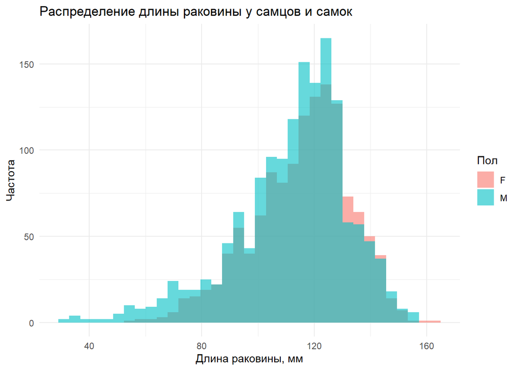

```r
#Гистограмма распределения длин
ggplot(моллюски_мж, aes(x = Length, fill = Sex)) +
  geom_histogram(alpha = 0.6, position = "identity", bins = 35) +
  labs(
    title = "Распределение длины раковины у самцов и самок",
    x = "Длина раковины, мм",
    y = "Частота",
    fill = "Пол"
  ) +
  theme_minimal()
```

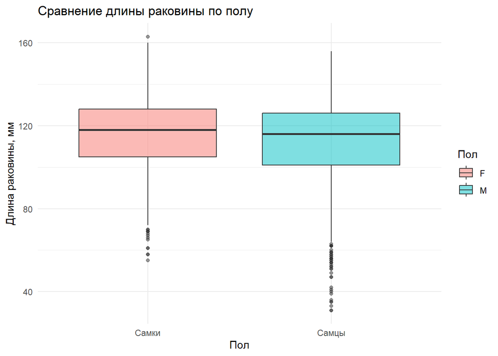

```r
#Бокс-плот для сравнения групп
ggplot(моллюски_мж, aes(x = Sex, y = Length, fill = Sex)) +
  geom_boxplot(alpha = 0.5) +
  labs(
    title = "Сравнение длины раковины по полу",
    x = "Пол",
    y = "Длина раковины, мм",
    fill = "Пол"
  ) +
  theme_minimal() +
  scale_x_discrete(labels = c("M" = "Самцы", "F" = "Самки"))
```

### Задание 1.3

Выберите подходящий тип доверительного интервала и объясните, почему он соответствует исследовательскому вопросу.

Для ответа на исследовательский вопрос подходящим является двухвыборочный доверительный интервал для разности средних двух независимых выборок. Самцы и самки представляют собой две независимые группы. Один и тот же моллюск не может одновременно быть самцом и самкой (данных о гермофродитизме моллюсков не было), поэтому данные не являются парными или связанными. Если этот интервал не содержит ноль, мы отклоняем нулевую гипотезу и делаем вывод о наличии статистически значимых различий. Если ноль попадает в интервал, мы не отклоняем нулевую гипотезу.

### Задание 1.4

Постройте выбранный доверительный интервал для проверки поставленной гипотезы

```r
test_result <- t.test(Length ~ Sex, data = моллюски_мж, conf.level = 0.95)
ci_bounds <- test_result$conf.int
```

### Задание 1.5

На основании доверительного интервала проверьте сформулированную гипотезу. Объясните результат и решение.

Средняя длина раковины самок составляет 115.82 мм, а самцов 112.28 мм. Наблюдаемая разность средних равна 3.54 мм. 95% доверительный интервал для истинной разности средних в генеральной совокупности составляет [2.149486; 4.931569] мм. Поскольку построенный 95% доверительный интервал не содержит значение 0 (оба его предела положительны), мы не принимаем нулевую гипотезу об отсутствии различий/равенстве различий в средней длине раковины между самцами и самками на уровне значимости α = 0.05, дополнительно это подтверждается очень маленьким p-value. То есть с уществуют статистически значимые различия в длине раковины между полами. С 95% уверенностью можно утверждать, что в генеральной совокупности самки морских моллюсков Haliotis имеют раковину в среднем на 2.15 – 4.93 мм длиннее, чем самцы.

Что можно сказать о направлении и величине различия? Совпадает ли результат с вашим впечатлением от графика в задании 1.2? Как вы думаете, почему?

Результат совпадает с тем, что было видно на графиках, но на первый взгляд это не было очевидно. На гистограммах и boxplot было заметно, что распределение самок смещено в сторону больших значений, но смещение было небольшим и со стороны результаты не казалось значимыми, но если вспомнить, что в выборке более 2800 наблюдений, всё становится на свои места. Большой размер выборки обеспечивает высокую статистическую мощность теста. Это означает, что даже небольшое по абсолютной величине различие становится статистически значимым

## 2. Сравнение массы съедобной части моллюска у самцов и самок

Исследователи предположили, что средняя масса съедобной части моллюска у самцов **больше**, чем у самок. Проверьте это предположение.

### Задание 2.1

Укажите, какой параметр генеральной совокупности вы оцениваете. Сформулируйте нулевую и альтернативную гипотезы.

> Обратите внимание на порядок вычитания средних: он определяет знак разности и её интерпретацию.

Параметр ГС: разность между средней массой съедобной части моллюска у самцов и самок в ГС. Ожидаем получить положительное значение разности, если альтернативная гипотеза верна. Это означает, что мы будем проводить односторонний (правосторонний) тест. - $H_0$: Средняя масса съедобной части у самцов не превышает(меньше или =) среднюю массу у самок - $H_a$: Средняя масса съедобной части у самцов строго больше, чем у самок

### Задание 2.2

Выберите и рассчитайте описательные статистики, необходимые для исследования вопроса.

Визуализируйте распределения исследуемого признака у самцов и самок. Кратко опишите особенности распределений. Предположите по графикам, больше ли средняя масса съедобной части моллюска у самцов, чем у самок.

```r
#Только самцы
n_мужчин <- nrow(males)
mean_масса_мужчин <- mean(males$Shucked_weight)
median_масса_мужчин <- median(males$Shucked_weight)
sd_масса_мужчин <- sd(males$Shucked_weight)
min_масса_мужчин <- min(males$Shucked_weight)
max_масса_мужчин <- max(males$Shucked_weight)
q25_мужчин <- quantile(males$Shucked_weight, 0.25)
q75_мужчин <- quantile(males$Shucked_weight, 0.75)

#Только самки
n_женщин <- nrow(females)
mean_масса_женщин <- mean(females$Shucked_weight)
median_масса_женщин <- median(females$Shucked_weight)
sd_масса_женщин <- sd(females$Shucked_weight)
min_масса_женщин <- min(females$Shucked_weight)
max_масса_женщин <- max(females$Shucked_weight)
q25_женщин <- quantile(females$Shucked_weight, 0.25)
q75_женщин <- quantile(females$Shucked_weight, 0.75)
```

```r
#Таблица со статистиками
статистика_масса <- data.frame(
  Sex = c("M (самцы)", "F (самки)"),
  n = c(n_мужчин, n_женщин),
  Mean = c(mean_масса_мужчин, mean_масса_женщин),
  Median = c(median_масса_мужчин, median_масса_женщин),
  SD = c(sd_масса_мужчин, sd_масса_женщин),
  Min = c(min_масса_мужчин, min_масса_женщин),
  Max = c(max_масса_мужчин, max_масса_женщин),
  Q25 = c(q25_мужчин, q25_женщин),
  Q75 = c(q75_мужчин, q75_женщин)
)
```

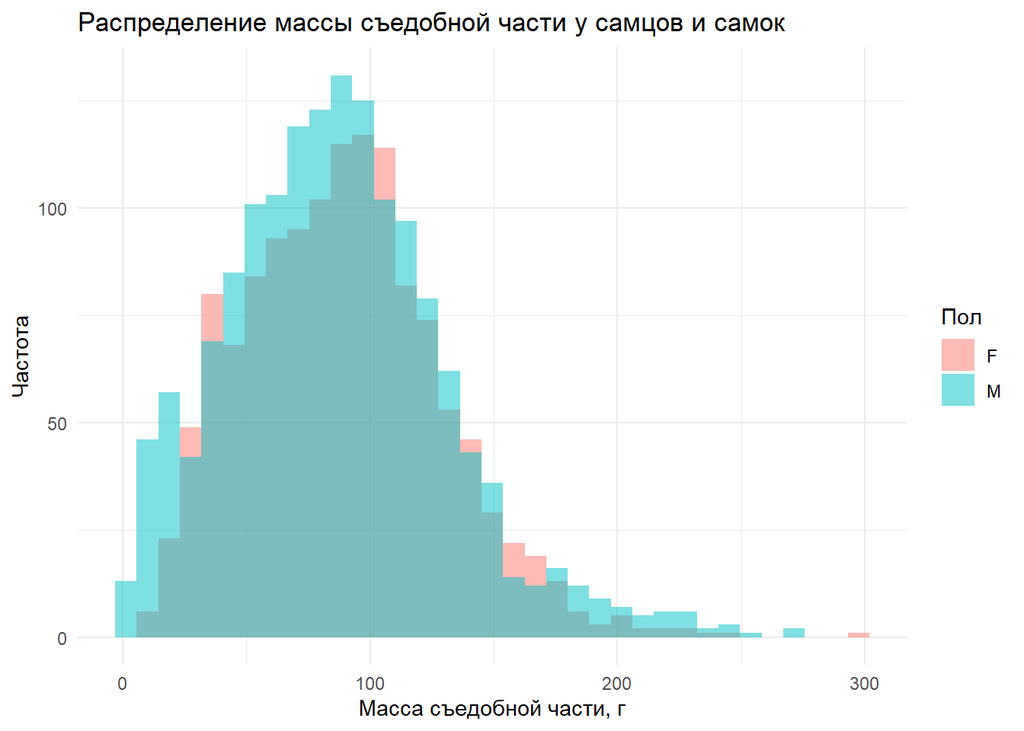

```r
#Гистограмма распределения массы съедобной части
ggplot(моллюски_мж, aes(x = Shucked_weight, fill = Sex)) +
  geom_histogram(alpha = 0.5, position = "identity", bins = 35) +
  labs(
    title = "Распределение массы съедобной части у самцов и самок",
    x = "Масса съедобной части, г",
    y = "Частота",
    fill = "Пол"
  ) +
  theme_minimal()
```

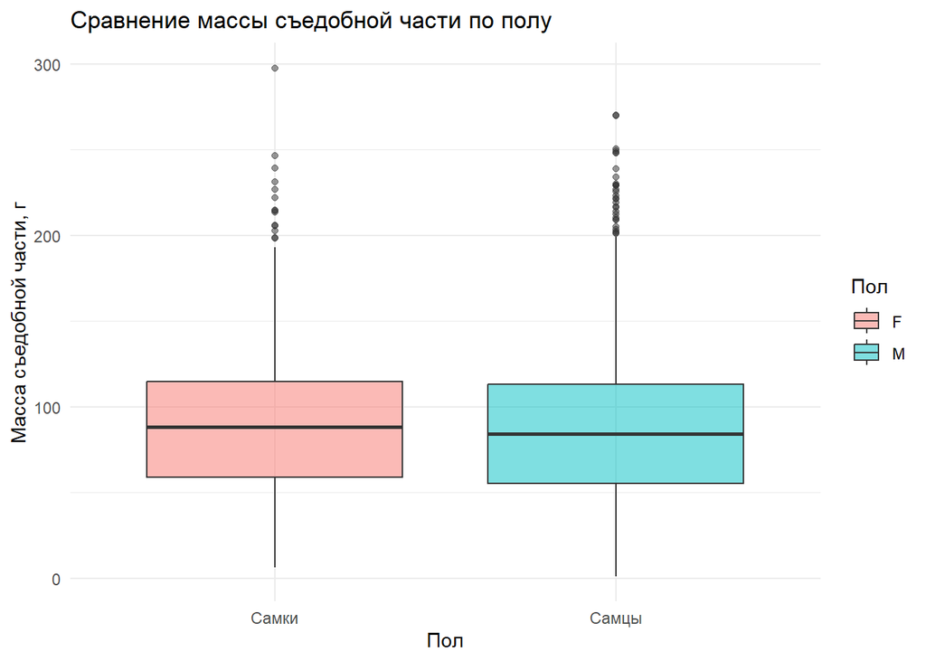

```r
# Бокс-плот для сравнения групп
ggplot(моллюски_мж, aes(x = Sex, y = Shucked_weight, fill = Sex)) +
  geom_boxplot(alpha = 0.5) +
  labs(
    title = "Сравнение массы съедобной части по полу",
    x = "Пол",
    y = "Масса съедобной части, г",
    fill = "Пол"
  ) +
  theme_minimal() +
  scale_x_discrete(labels = c("M" = "Самцы", "F" = "Самки"))
```

На гистограмме правосторонний скос, так как хвост тянется вправо к большим значениям массы. Большинство особей имеют средние/небольшие размеры, а крупные особи встречаются реже, создавая длинный правый хвост. Медианы обеих групп очень близки (около 85-90 г). Межквартильный размах и общий разброс похожи в обеих группах. Распределения сильно перекрываются - гистограммы практически совпадают по форме. Самцов значительно больше, чем самок (отмечалось ранее)

### Задание 2.3

Выберите подходящий тип доверительного интервала и объясните, почему он соответствует исследовательскому вопросу.

Для ответа на исследовательский вопрос подходящим является односторонний доверительный интервал для разности средних двух независимых выборок. амцы и самки — это две разные, независимые группы. Один и тот же моллюск не может быть одновременно самцом и самкой, поэтому данные не являются парными (данных о гермафродитизме не было, ранее писала об этом). В отличие от первого задания, здесь исследователи проверяют конкретное предположение: масса у самцов строго больше, чем у самок. Это означает, что нам нужен именно односторонний интервал (мы оцениваем только нижнюю границу разности), а не двусторонний. Мы заранее не знаем, одинаков ли разброс (дисперсия) массы у самцов и самок - тест Уэлча

### Задание 2.4

Постройте выбранный доверительный интервал для проверки поставленной гипотезы

```r
моллюски_мж$Sex <- factor(моллюски_мж$Sex, levels = c("M", "F"))
test_shucked <- t.test(Shucked_weight ~ Sex, data = моллюски_мж,
                       alternative = "greater", conf.level = 0.95)
ci_lower_bound <- test_shucked$conf.int[1]
test_shucked
```

```
    Welch Two Sample t-test

data:  Shucked_weight by Sex
t = -1.6717, df = 2828.3, p-value = 0.9527
alternative hypothesis: true difference in means between group M and group F is greater than 0
95 percent confidence interval:
 -5.254988       Inf
sample estimates:
mean in group M mean in group F
       86.58920        89.23757
```

```r
ci_lower_bound
```

```
[1] -5.254988
```

### Задание 2.5

На основании доверительного интервала проверьте сформулированную гипотезу. Поддерживают ли данные заявленное предположение?

Нижняя граница одностороннего 95% доверительного интервала для истинной разности средних в ГС составляет -5.25 г. У нас нет статистических оснований полагать, что средняя масса съедобной части моллюска у самцов больше, чем у самок. Исходное предположение исследователей не подтверждается. Более того, выборочные данные указывают на обратную тенденцию (самки в среднем тяжелее)

Что можно сказать о направлении и величине различия? Совпадает ли результат с вашим впечатлением от графика в задании 2.2? Как вы думаете, почему?

## 3. Сравнение массы раковины незрелых особей и самок

Исследователи предположили, что средняя масса раковины *незрелых* особей **меньше**, чем у *самок*. Проверьте, поддерживают ли данные это предположение.

### Задание 3.1

Укажите, какой параметр генеральной совокупности вы оцениваете. Сформулируйте нулевую и альтернативную гипотезы.

Параметр ГС: разность между средней массой раковины незрелых особей и самок в генеральной совокупности. Поскольку проверяем конкретное направление различия (меньше), мы будем проводить односторонний тест.

- $H_0$: Средняя масса раковины незрелых особей больше или равна средней массе раковины самок
- $H_a$: Средняя масса раковины незрелых особей строго меньше средней массы раковины самок

### Задание 3.2

Выберите и рассчитайте описательные статистики, необходимые для исследования этого вопроса.

Визуализируйте распределения исследуемого признака у незрелых особей и самок. Кратко опишите особенности распределений. Предположите по графикам, меньше ли средняя масса раковины у незрелых особей, чем у самок.

```r
моллюски_иж <- filter(моллюски, Sex %in% c("I", "F"))
моллюски_иж$Sex <- factor(моллюски_иж$Sex, levels = c("I", "F"))
# Разделяем на две группы
незрелые <- filter(моллюски_иж, Sex == "I")
самки <- filter(моллюски_иж, Sex == "F")

# Описываем незрелых
n_I <- nrow(незрелые)
mean_масса_незрелые <- mean(незрелые$Shell_weight)
median_масса_незрелые <- median(незрелые$Shell_weight)
sd_масса_незрелые <- sd(незрелые$Shell_weight)
min_масса_незрелые <- min(незрелые$Shell_weight)
max_масса_незрелые <- max(незрелые$Shell_weight)
q25_масса_незрелые <- quantile(незрелые$Shell_weight, 0.25)
q75_масса_незрелые <- quantile(незрелые$Shell_weight, 0.75)

# Описываем самок
n_F <- nrow(самки)
mean_масса_самки <- mean(самки$Shell_weight)
median_масса_самки <- median(самки$Shell_weight)
sd_масса_самки <- sd(самки$Shell_weight)
min_масса_самки <- min(самки$Shell_weight)
max_масса_самки <- max(самки$Shell_weight)
q25_масса_самки <- quantile(самки$Shell_weight, 0.25)
q75_масса_самки <- quantile(самки$Shell_weight, 0.75)
```

```r
#Таблица со статистиками
статистика_раковина <- data.frame(
  Sex = c("I (незрелые)", "F (самки)"),
  n = c(n_I, n_F),
  Mean = c(mean_масса_незрелые, mean_масса_самки),
  Median = c(median_масса_незрелые, median_масса_самки),
  SD = c(sd_масса_незрелые, sd_масса_самки),
  Min = c(min_масса_незрелые, min_масса_самки),
  Max = c(max_масса_незрелые, max_масса_самки),
  Q25 = c(q25_масса_незрелые, q25_масса_самки),
  Q75 = c(q75_масса_незрелые, q75_масса_самки)
)
print(статистика_раковина)
```

```
           Sex    n     Mean Median       SD Min Max    Q25  Q75
1 I (незрелые) 1342 25.63644   22.6 16.98542 0.3 131 12.825 35.7
2    F (самки) 1307 60.40199   59.0 25.12972 5.0 201 42.650 75.0
```

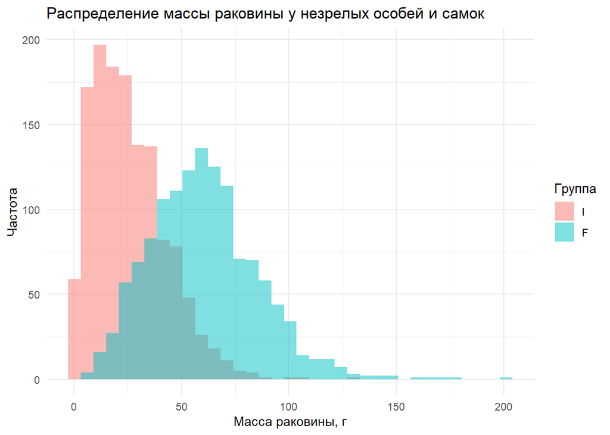

```r
# Гистограмма распределения массы раковины
ggplot(моллюски_иж, aes(x = Shell_weight, fill = Sex)) +
  geom_histogram(alpha = 0.5, position = "identity", bins = 35) +
  labs(
    title = "Распределение массы раковины у незрелых особей и самок",
    x = "Масса раковины, г",
    y = "Частота",
    fill = "Группа"
  ) +
  theme_minimal()
```

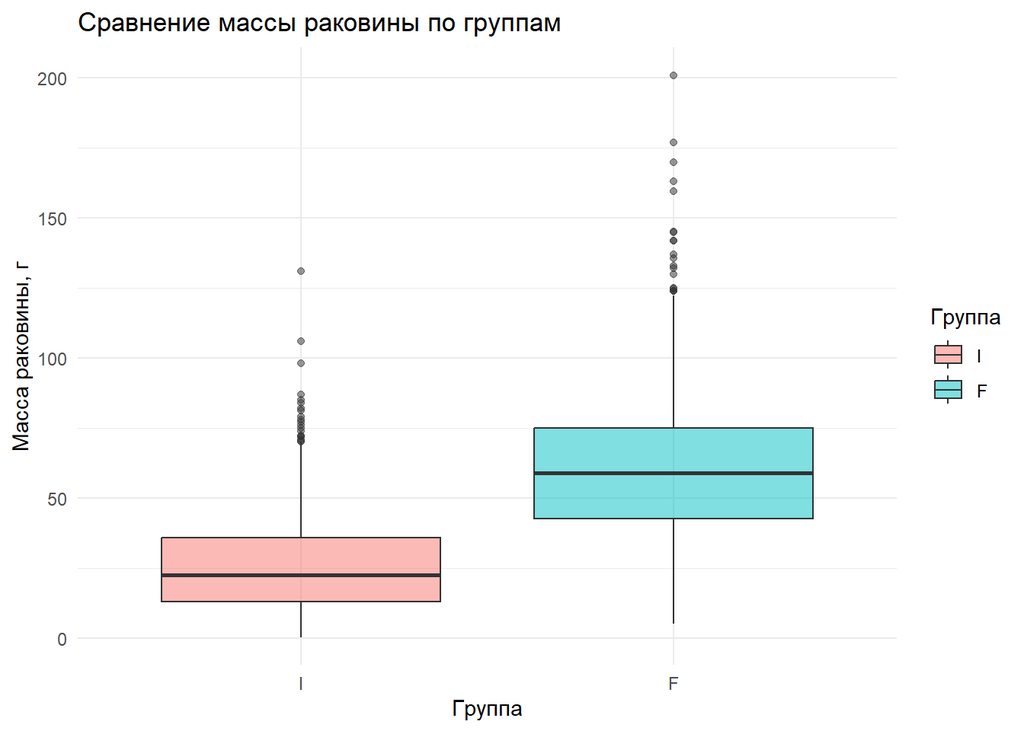

```r
# Бокс-плот для сравнения групп
ggplot(моллюски_иж, aes(x = Sex, y = Shell_weight, fill = Sex)) +
  geom_boxplot(alpha = 0.5) +
  labs(
    title = "Сравнение массы раковины по группам",
    x = "Группа",
    y = "Масса раковины, г",
    fill = "Группа"
  ) +
  theme_minimal()
```

### Задание 3.3

Выберите подходящий статистический критерий. Самостоятельно рассчитайте его наблюдаемую статистику и необходимые критические значения при заданном уровне значимости. Укажите критическую область.

Не используйте функции, выполняющие готовую проверку гипотез. Функции для вычисления квантилей распределений использовать можно. Вычислять p-значение в этом задании не нужно.

```r
#Извлекаем необходимые значения из предыдущих шагов
n1 <- n_I
n2 <- n_F
mean1 <- mean_масса_незрелые
mean2 <- mean_масса_самки
var1 <- sd_масса_незрелые^2
var2 <- sd_масса_самки^2
```

```r
#Объединенная дисперсия (pooled variance)
sp_squared <- ((n1 - 1) * var1^2 + (n2 - 1) * var2^2) / (n1 + n2 - 2)

#Стандартная ошибка с pooled variance
se_pooled <- sqrt(sp_squared * (1/n1 + 1/n2))

#t-статистика
t_obs <- (mean1 - mean2) / se_pooled
df <- n1 + n2 - 2

# Критическое значение
alpha <- 0.05
t_crit <- qt(alpha, df)

cat("Наблюдаемая t-статистика:", t_obs, "\n")
```

```
Наблюдаемая t-статистика: -1.830153
```

```r
cat("Степени свободы:", df, "\n")
```

```
Степени свободы: 2647
```

```r
cat("Критическое значение t:", t_crit, "\n")
```

```
Критическое значение t: -1.645429
```

```r
cat("Критическая область: t <", t_crit, "\n")
```

```
Критическая область: t < -1.645429
```

### Задание 3.4

На основании полученных результатов сформулируйте вывод относительно нулевой гипотезы и обоснуйте своё решение. Поддерживают ли данные предположение исследователей?

Наблюдаемое значение t-статистики (−1.83) меньше критического значения (−1.645). Поскольку расчетная статистика попадает в критическую область мы не принимаем нулевую гипотезу на уровне значимости 0.05. Следовательно, данные статистически значимо поддерживают предположение исследователей: средняя масса раковины незрелых особей действительно меньше, чем у самок.

Что можно сказать о направлении и величине различия? Совпадает ли результат с вашим впечатлением от графика в задании 3.2? Как вы думаете, почему?